# Bangladesh Adaptation Observation Duplicate IP Address Survey Responses, Retrieval Date 15 April 2024.

Autogenerated data summary from dataMaid

2024-04-21 23:35:57.439618

# Data report overview

The dataset examined has the following dimensions:

| Feature | Result |
| --- | --- |
| Number of observations | 612 |
| Number of variables | 60 |

### Checks performed

The following variable checks were performed, depending on the data type of each variable:

|  | character | factor | labelled | haven labelled | numeric | integer | logical | Date |
| --- | --- | --- | --- | --- | --- | --- | --- | --- |
| Identify miscoded missing values | × | × | × | × | × | × |  | × |
| Identify prefixed and suffixed whitespace | × | × | × | × |  |  |  |  |
| Identify levels with < 6 obs. | × | × | × | × |  |  |  |  |
| Identify case issues | × | × | × | × |  |  |  |  |
| Identify misclassified numeric or integer variables | × | × | × | × |  |  |  |  |
| Identify outliers |  |  |  |  | × | × |  | × |

Please note that all numerical values in the following have been rounded to 2 decimals.

# Summary table

|  | Variable class | # unique values | Missing observations | Any problems? |
| --- | --- | --- | --- | --- |
| start_date | character | 611 | 0.00 % | × |
| end_date | character | 611 | 0.00 % | × |
| status | character | 1 | 0.00 % | × |
| ip_address | character | 229 | 0.00 % | × |
| progress | character | 1 | 0.00 % | × |
| duration_in_seconds | character | 401 | 0.00 % | × |
| finished | character | 1 | 0.00 % | × |
| recorded_date | character | 611 | 0.00 % | × |
| response_id | character | 612 | 0.00 % | × |
| recipient_last_name | character | 1 | 100.00 % | × |
| recipient_first_name | character | 1 | 100.00 % | × |
| recipient_email | character | 1 | 100.00 % | × |
| external_reference | character | 1 | 100.00 % | × |
| location_latitude | numeric | 48 | 0.00 % | × |
| location_longitude | numeric | 48 | 0.00 % | × |
| distribution_channel | character | 1 | 0.00 % | × |
| user_language | character | 2 | 0.00 % |  |
| meta_info_browser | character | 5 | 0.00 % | × |
| meta_info_version | character | 51 | 0.00 % | × |
| meta_info_operating_system | character | 17 | 0.00 % | × |
| meta_info_resolution | character | 90 | 0.00 % | × |
| consent_agreed | character | 1 | 0.00 % | × |
| consent_age | character | 1 | 0.00 % | × |
| consent_cellphone | character | 1 | 0.00 % | × |
| gps_permission | character | 1 | 0.00 % | × |
| household_move | character | 2 | 0.00 % |  |
| flood_year | character | 3 | 0.33 % |  |
| property_loss | character | 3 | 60.29 % |  |
| housing_damage | character | 3 | 60.78 % |  |
| stay_residence | character | 3 | 60.78 % |  |
| flood_close | character | 3 | 40.03 % |  |
| flood_prepared | character | 6 | 1.14 % |  |
| housing_safe | character | 6 | 1.80 % |  |
| climate_problem | character | 6 | 1.80 % |  |
| trust_government | character | 6 | 1.31 % |  |
| enough_eat | character | 3 | 0.33 % |  |
| move_rural_urban | character | 2 | 0.00 % |  |
| contact_authority | character | 3 | 0.33 % |  |
| demo_gender | character | 3 | 0.00 % | × |
| demo_age | character | 119 | 0.65 % | × |
| demo_income | character | 207 | 0.98 % | × |
| comp_phone1_try1 | character | 567 | 0.00 % | × |
| comp_phone1_try2 | character | 567 | 0.00 % | × |
| comp_phone2_try1 | character | 36 | 94.12 % | × |
| comp_phone2_try2 | character | 37 | 94.12 % | × |
| comp_phone3_try1 | character | 6 | 99.02 % | × |
| comp_phone3_try2 | character | 6 | 99.02 % | × |
| geo_lat | character | 214 | 62.58 % | × |
| geo_lng | character | 214 | 62.58 % | × |
| q_url | character | 514 | 0.00 % | × |
| q_language | character | 2 | 0.00 % |  |
| gender | character | 3 | 8.66 % |  |
| region | character | 11 | 8.66 % |  |
| age | character | 4 | 8.66 % |  |
| geo_capability | character | 1 | 100.00 % | × |
| geo_status | character | 3 | 0.00 % |  |
| geo_error | character | 2 | 50.33 % | × |
| country | character | 1 | 100.00 % | × |
| no_surverys_submitted | integer | 8 | 0.00 % |  |
| income_brackets | character | 5 | 0.98 % |  |

# Variable list

## start_date

| Feature | Result |
| --- | --- |
| Variable type | character |
| Number of missing obs. | 0 (0 %) |
| Number of unique values | 611 |
| Mode | “2024-03-26 12:07:28” |

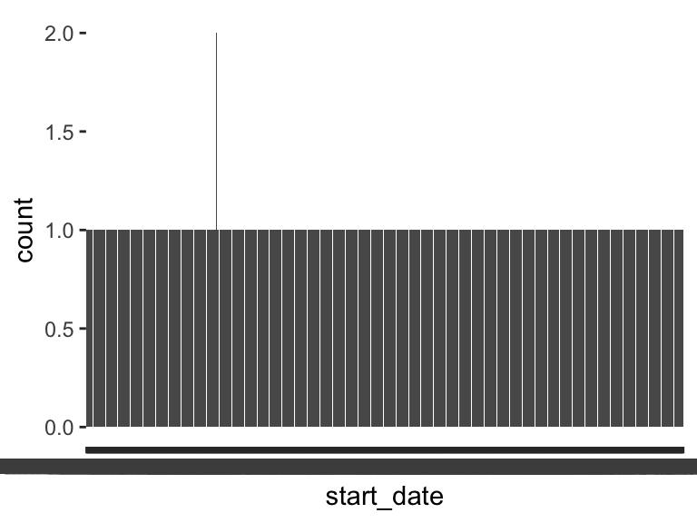

- Note that the following levels have at most five observations: "2024-03-25 20:30:07", "2024-03-25 20:47:12", "2024-03-25 20:57:47", "2024-03-25 20:57:57", "2024-03-25 21:03:02", …, "2024-04-05 12:11:34", "2024-04-05 12:11:51", "2024-04-05 12:11:56", "2024-04-05 12:12:01", "2024-04-05 12:35:39" (601 values omitted).

## end_date

| Feature | Result |
| --- | --- |
| Variable type | character |
| Number of missing obs. | 0 (0 %) |
| Number of unique values | 611 |
| Mode | “2024-03-26 22:03:12” |

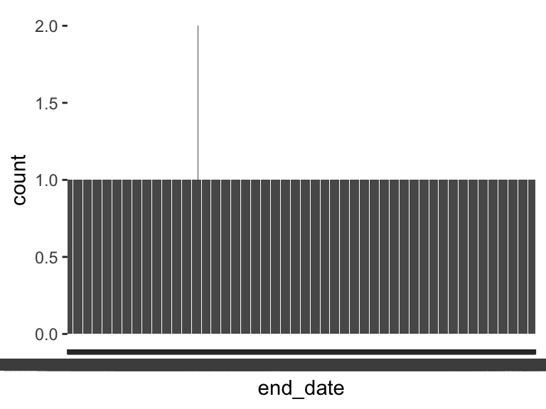

- Note that the following levels have at most five observations: "2024-03-25 20:36:34", "2024-03-25 20:52:32", "2024-03-25 21:01:00", "2024-03-25 21:02:02", "2024-03-25 21:06:22", …, "2024-04-05 12:29:00", "2024-04-05 12:34:05", "2024-04-05 12:34:41", "2024-04-05 12:35:22", "2024-04-05 12:38:01" (601 values omitted).

## status

- The variable only takes one (non-missing) value: "IP Address". The variable contains 0 % missing observations.

## ip_address

| Feature | Result |
| --- | --- |
| Variable type | character |
| Number of missing obs. | 0 (0 %) |
| Number of unique values | 229 |
| Mode | “103.146.42.192” |

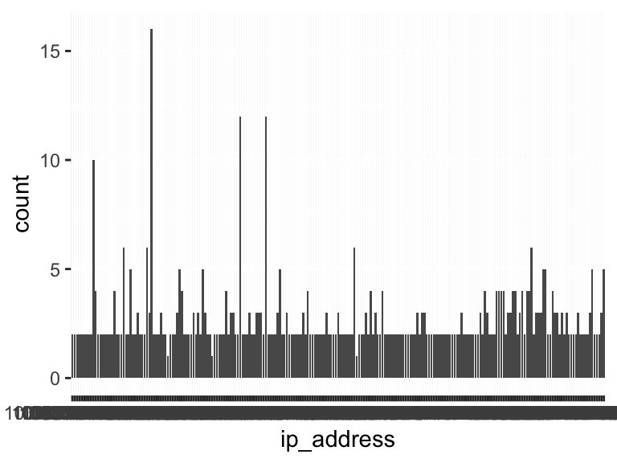

- Note that the following levels have at most five observations: "101.2.167.130", "103.100.235.143", "103.101.253.17", "103.107.76.83", "103.107.78.97", …, "58.145.190.241", "58.145.190.243", "58.145.190.244", "58.145.190.250", "58.145.190.253" (211 values omitted).

## progress

- The variable only takes one (non-missing) value: "100". The variable contains 0 % missing observations.

## duration_in_seconds

| Feature | Result |
| --- | --- |
| Variable type | character |
| Number of missing obs. | 0 (0 %) |
| Number of unique values | 401 |
| Mode | “230” |

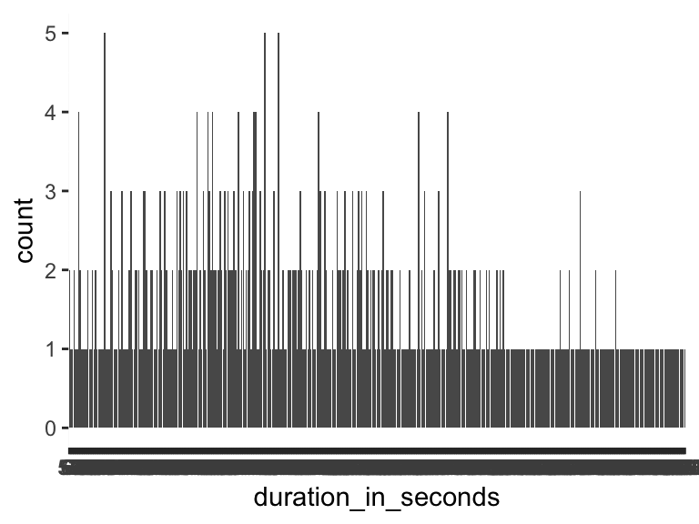

- Note that the following levels have at most five observations: "100", "1009", "101", "1045", "105", …, "95", "97", "974", "986", "99" (391 values omitted).
- Note: The variable consists exclusively of numbers and takes a lot of different values. Is it perhaps a misclassified numeric variable?

## finished

- The variable only takes one (non-missing) value: "True". The variable contains 0 % missing observations.

## recorded_date

| Feature | Result |
| --- | --- |
| Variable type | character |
| Number of missing obs. | 0 (0 %) |
| Number of unique values | 611 |
| Mode | “2024-03-26 22:03:13” |

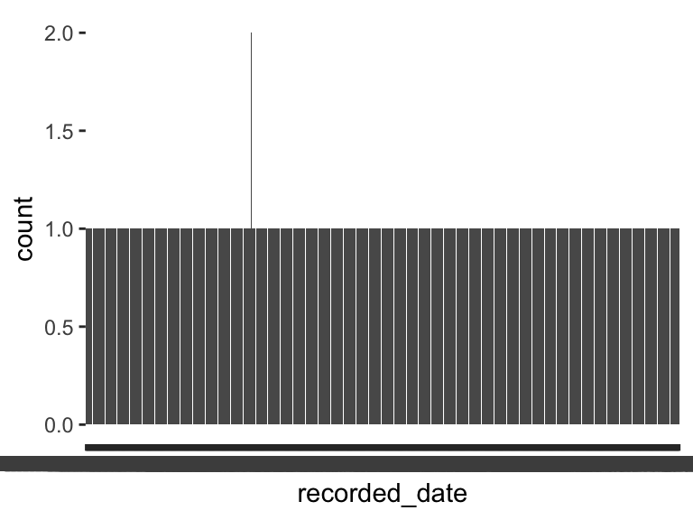

- Note that the following levels have at most five observations: "2024-03-25 20:36:35", "2024-03-25 20:52:33", "2024-03-25 21:01:01", "2024-03-25 21:02:03", "2024-03-25 21:06:23", …, "2024-04-05 12:29:00", "2024-04-05 12:34:05", "2024-04-05 12:34:42", "2024-04-05 12:35:23", "2024-04-05 12:38:01" (601 values omitted).

## response_id

- The variable is a key (distinct values for each observation).

## recipient_last_name

- The variable only takes one value: "NA".

## recipient_first_name

- The variable only takes one value: "NA".

## recipient_email

- The variable only takes one value: "NA".

## external_reference

- The variable only takes one value: "NA".

## location_latitude

| Feature | Result |
| --- | --- |
| Variable type | numeric |
| Number of missing obs. | 0 (0 %) |
| Number of unique values | 48 |
| Median | 23.73 |
| 1st and 3rd quartiles | 23.73; 24.48 |
| Min. and max. | 22.35; 25.52 |

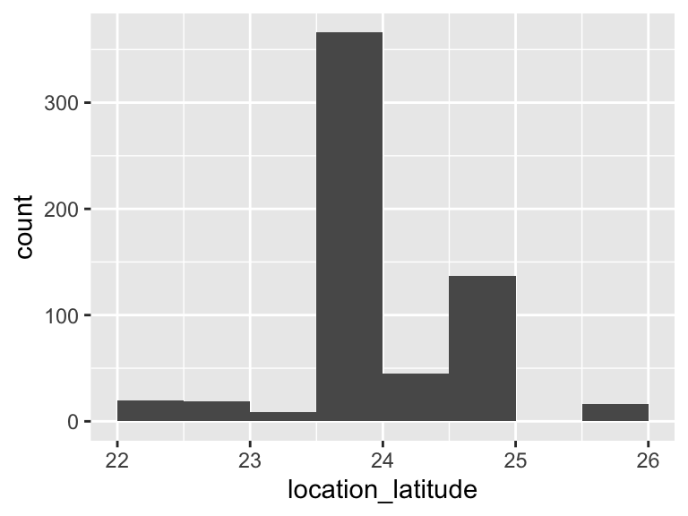

- Note that the following possible outlier values were detected: "22.35", "22.39", "22.5", "22.63", "22.81", …, "23.38", "23.54", "23.65", "23.7", "23.7" (4 values omitted).

## location_longitude

| Feature | Result |
| --- | --- |
| Variable type | numeric |
| Number of missing obs. | 0 (0 %) |
| Number of unique values | 48 |
| Median | 90.41 |
| 1st and 3rd quartiles | 90.37; 90.83 |
| Min. and max. | 88.6; 92.23 |

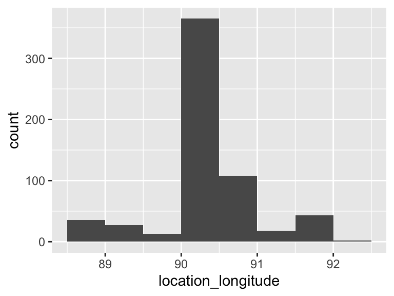

- Note that the following possible outlier values were detected: "88.6", "88.61", "88.95", "89.15", "89.2", …, "89.57", "89.7", "89.71", "90.04", "90.24" (5 values omitted).

## distribution_channel

- The variable only takes one (non-missing) value: "anonymous". The variable contains 0 % missing observations.

## user_language

| Feature | Result |
| --- | --- |
| Variable type | character |
| Number of missing obs. | 0 (0 %) |
| Number of unique values | 2 |
| Mode | “BN” |

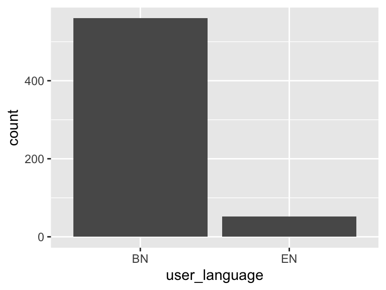

## meta_info_browser

| Feature | Result |
| --- | --- |
| Variable type | character |
| Number of missing obs. | 0 (0 %) |
| Number of unique values | 5 |
| Mode | “Chrome” |

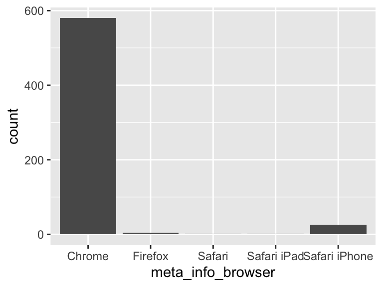

- Note that the following levels have at most five observations: "Firefox", "Safari", "Safari iPad".

## meta_info_version

| Feature | Result |
| --- | --- |
| Variable type | character |
| Number of missing obs. | 0 (0 %) |
| Number of unique values | 51 |
| Mode | “122.0.6261.136” |

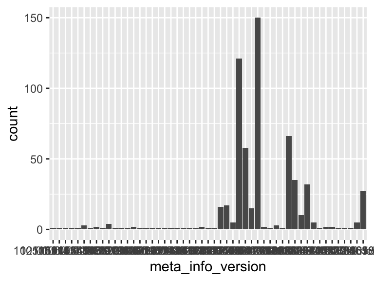

- Note that the following levels have at most five observations: "102.0.5005.125", "105.0.5195.136", "106.0.0.0", "106.0.5249.126", "109.0.5414.117", …, "124.0", "537.36", "74.0.3729.108", "77.0.3865.92", "95.0.4638.74" (30 values omitted).

## meta_info_operating_system

| Feature | Result |
| --- | --- |
| Variable type | character |
| Number of missing obs. | 0 (0 %) |
| Number of unique values | 17 |
| Mode | “Android 10” |

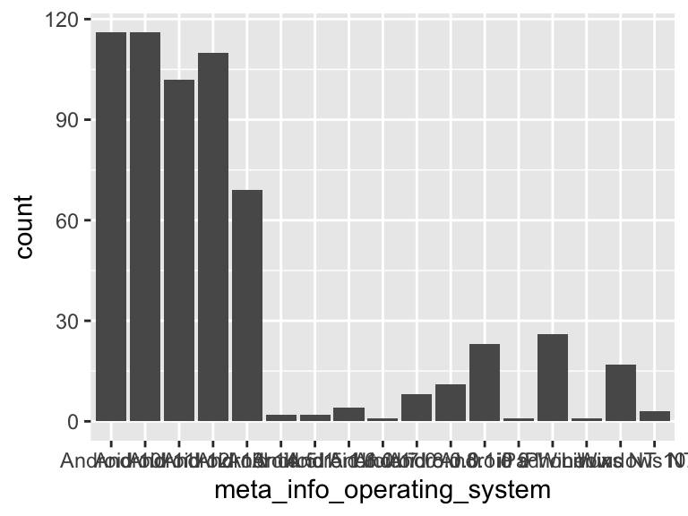

- Note that the following levels have at most five observations: "Android 5.1", "Android 5.1.1", "Android 6.0.1", "Android 7.0", "iPad", "Linux", "Windows NT 6.1".

## meta_info_resolution

| Feature | Result |
| --- | --- |
| Variable type | character |
| Number of missing obs. | 0 (0 %) |
| Number of unique values | 90 |
| Mode | “360x800” |

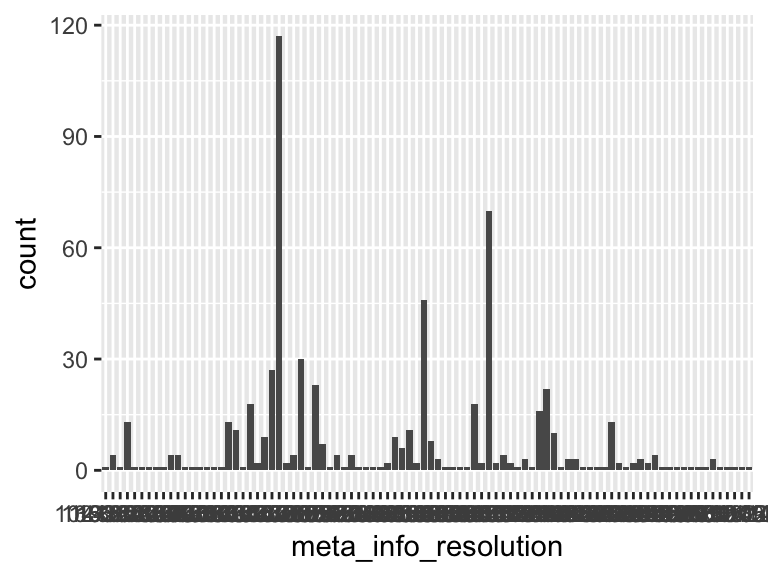

- Note that the following levels have at most five observations: "1024x640", "1366x768", "1418x798", "1920x1080", "320x427", …, "501x1114", "515x1058", "534x854", "582x1293", "768x1024" (59 values omitted).

## consent_agreed

- The variable only takes one (non-missing) value: "I agree to participate". The variable contains 0 % missing observations.

## consent_age

- The variable only takes one (non-missing) value: "Yes". The variable contains 0 % missing observations.

## consent_cellphone

- The variable only takes one (non-missing) value: "Yes". The variable contains 0 % missing observations.

## gps_permission

- The variable only takes one (non-missing) value: "Yes". The variable contains 0 % missing observations.

## household_move

| Feature | Result |
| --- | --- |
| Variable type | character |
| Number of missing obs. | 0 (0 %) |
| Number of unique values | 2 |
| Mode | “No” |

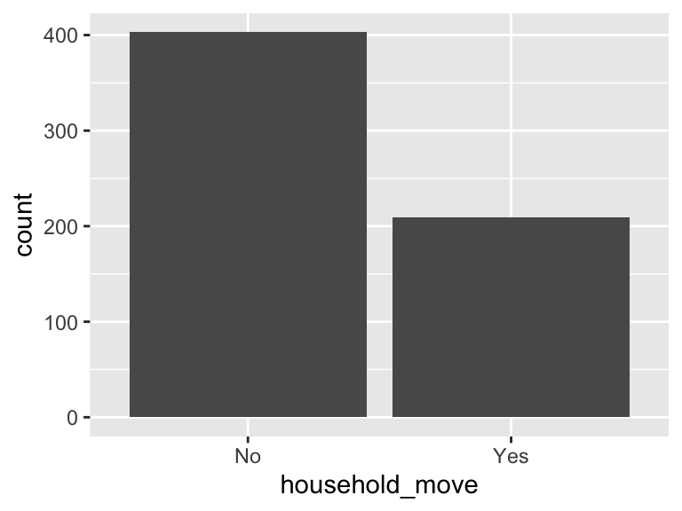

## flood_year

| Feature | Result |
| --- | --- |
| Variable type | character |
| Number of missing obs. | 2 (0.33 %) |
| Number of unique values | 2 |
| Mode | “No” |

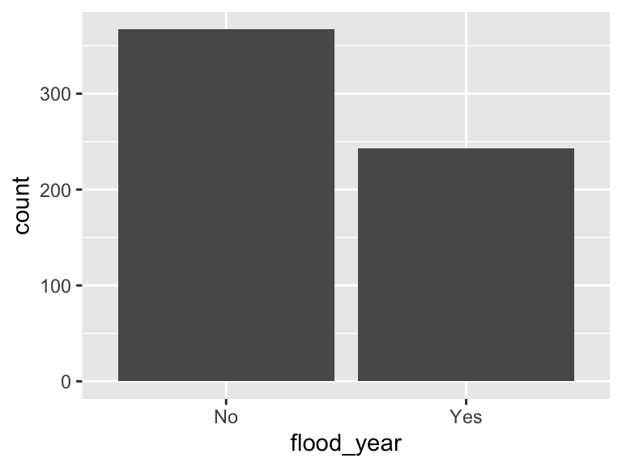

## property_loss

| Feature | Result |
| --- | --- |
| Variable type | character |
| Number of missing obs. | 369 (60.29 %) |
| Number of unique values | 2 |
| Mode | “Yes” |

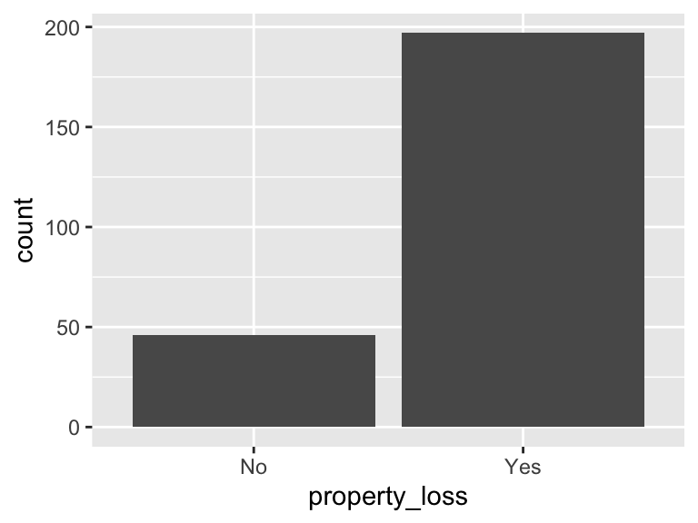

## housing_damage

| Feature | Result |
| --- | --- |
| Variable type | character |
| Number of missing obs. | 372 (60.78 %) |
| Number of unique values | 2 |
| Mode | “Yes” |

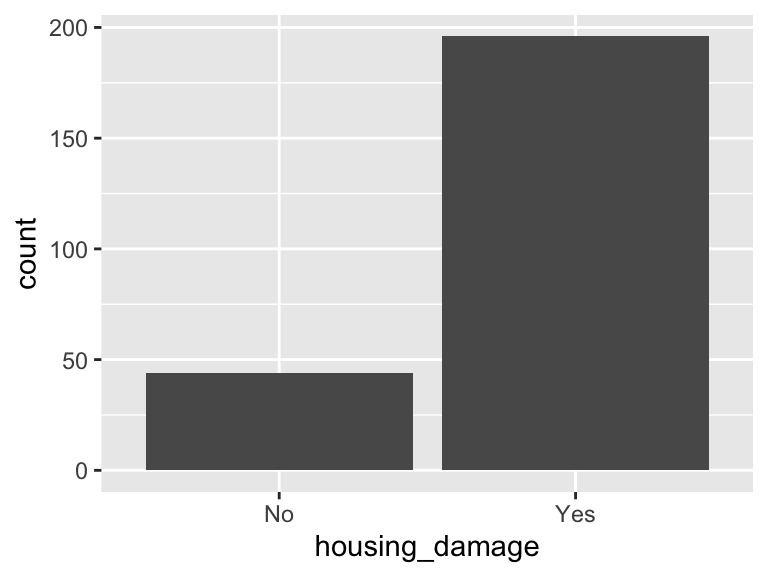

## stay_residence

| Feature | Result |
| --- | --- |
| Variable type | character |
| Number of missing obs. | 372 (60.78 %) |
| Number of unique values | 2 |
| Mode | “Yes” |

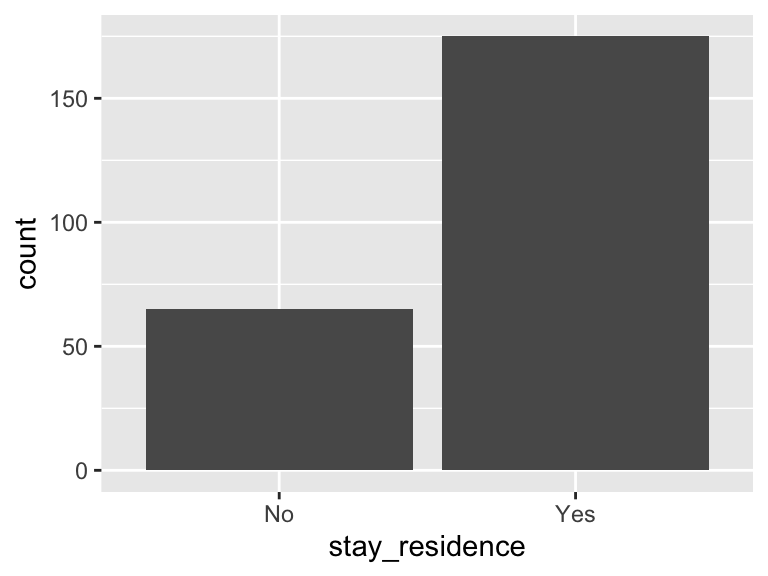

## flood_close

| Feature | Result |
| --- | --- |
| Variable type | character |
| Number of missing obs. | 245 (40.03 %) |
| Number of unique values | 2 |
| Mode | “No” |

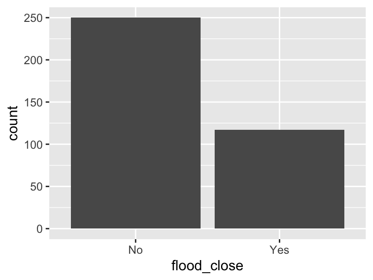

## flood_prepared

| Feature | Result |
| --- | --- |
| Variable type | character |
| Number of missing obs. | 7 (1.14 %) |
| Number of unique values | 5 |
| Mode | “Strongly agree” |

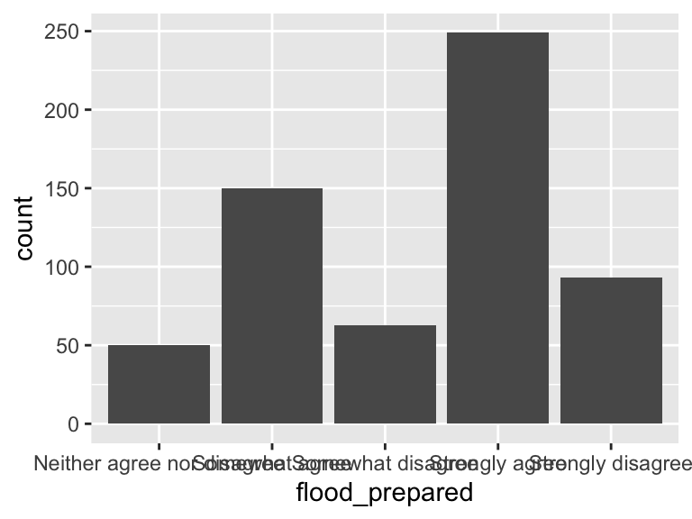

## housing_safe

| Feature | Result |
| --- | --- |
| Variable type | character |
| Number of missing obs. | 11 (1.8 %) |
| Number of unique values | 5 |
| Mode | “Strongly agree” |

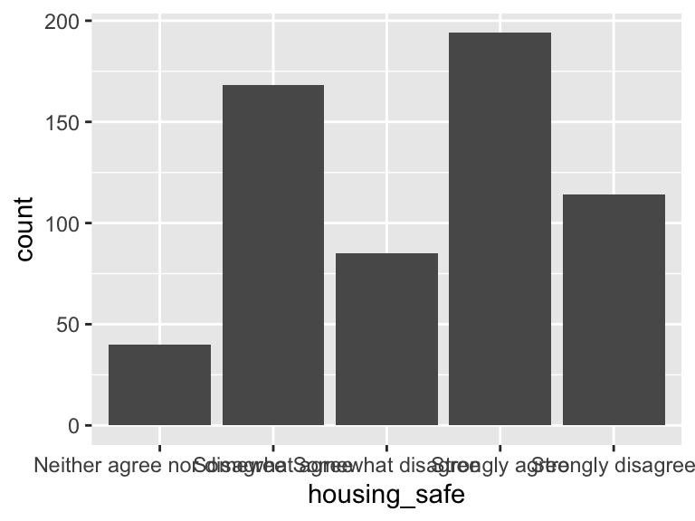

## climate_problem

| Feature | Result |
| --- | --- |
| Variable type | character |
| Number of missing obs. | 11 (1.8 %) |
| Number of unique values | 5 |
| Mode | “Strongly agree” |

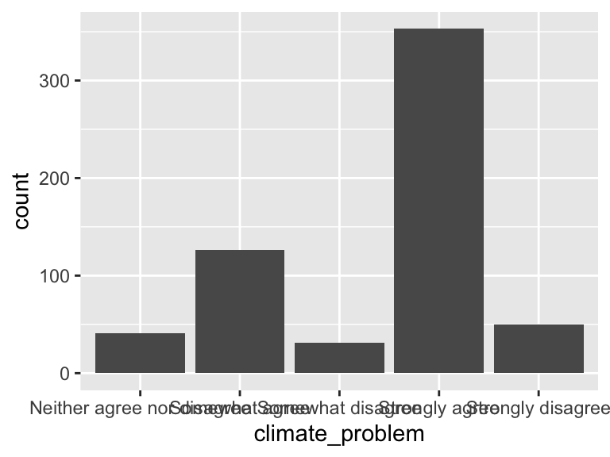

## trust_government

| Feature | Result |
| --- | --- |
| Variable type | character |
| Number of missing obs. | 8 (1.31 %) |
| Number of unique values | 5 |
| Mode | “Strongly agree” |

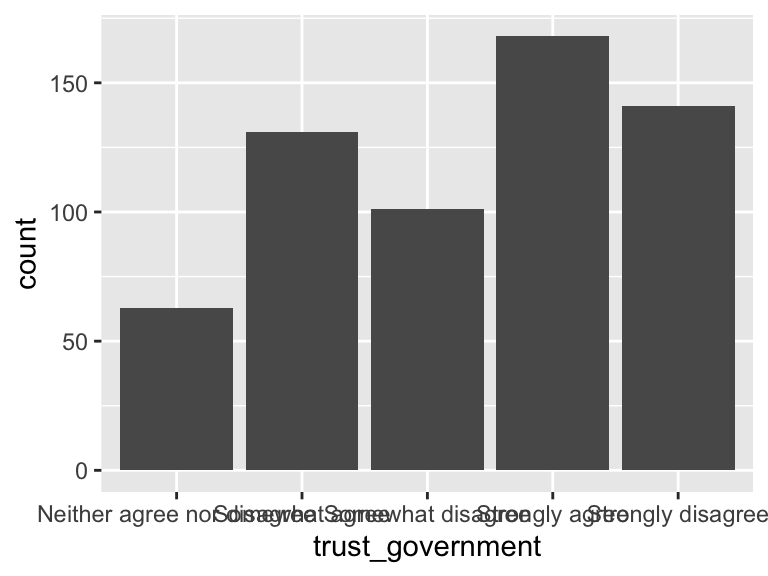

## enough_eat

| Feature | Result |
| --- | --- |
| Variable type | character |
| Number of missing obs. | 2 (0.33 %) |
| Number of unique values | 2 |
| Mode | “Yes” |

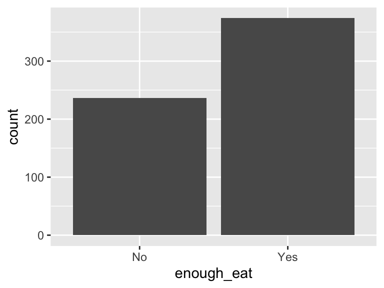

## move_rural_urban

| Feature | Result |
| --- | --- |
| Variable type | character |
| Number of missing obs. | 0 (0 %) |
| Number of unique values | 2 |
| Mode | “Yes” |

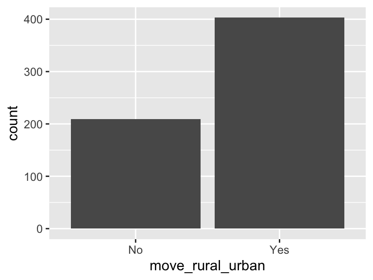

## contact_authority

| Feature | Result |
| --- | --- |
| Variable type | character |
| Number of missing obs. | 2 (0.33 %) |
| Number of unique values | 2 |
| Mode | “No” |

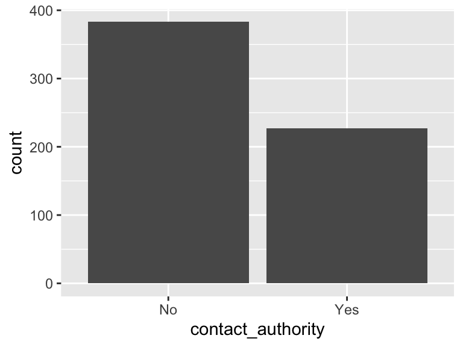

## demo_gender

| Feature | Result |
| --- | --- |
| Variable type | character |
| Number of missing obs. | 0 (0 %) |
| Number of unique values | 3 |
| Mode | “Male” |

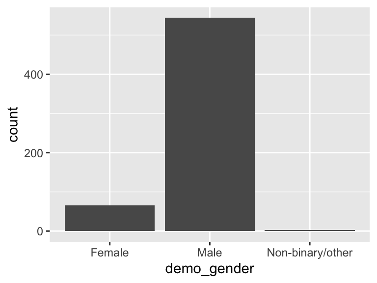

- Note that the following levels have at most five observations: "Non-binary/other".

## demo_age

| Feature | Result |
| --- | --- |
| Variable type | character |
| Number of missing obs. | 4 (0.65 %) |
| Number of unique values | 118 |
| Mode | “30” |

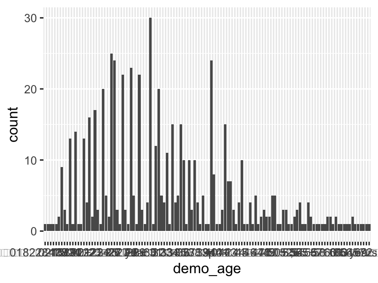

- Note that the following levels have at most five observations: "01822847824", "021", "০৪/১২/১৯৬৪ইং,।গত মাসে আমার স্ত্রীর চিকিৎসার জন্য মেডিকেলে দোড়াদড়িরজন্য কাজ করতে পারিনায়। এবং বর্তমানে ওরোগী হাসপাতালে,জরায়ু টিউমারের অপারেশন ,হয়েছে১মাসের বেশী ড্রেসিং চলতেছে।", "০৪/১২/১৯৬৪ইংমোটেওনা ঘরে রোগী থাকার কারনে।", "13", …, "৬৮ বছর।", "69", "৭০", "72", "৭৩" (81 values omitted).

## demo_income

| Feature | Result |
| --- | --- |
| Variable type | character |
| Number of missing obs. | 6 (0.98 %) |
| Number of unique values | 206 |
| Mode | “10000” |

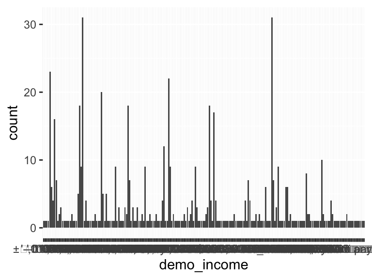

- Note that the following levels have at most five observations: "-10000", "‘-১০০০০", "’-৭৫০০", "±১,০০০০০/=", "0.00", …, "নাই", "মিনিমাম", "মোটেও না উল্টো দেনা আছি।", "ষাট হাজর টাকা", "হাঁ" (169 values omitted).

## comp_phone1_try1

| Feature | Result |
| --- | --- |
| Variable type | character |
| Number of missing obs. | 0 (0 %) |
| Number of unique values | 567 |
| Mode | “01734235237” |

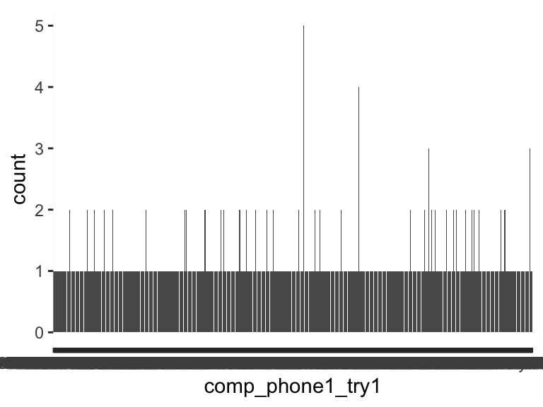

- Note that the following levels have at most five observations: "‘+৮৮০১৬০৫২২৮৩২২", "’+৮৮০১৭১২৫৫৮৮১১", "’+৮৮০১৯৩৩৮৪৩৪৬৪", "+88 01518758925", "+880 1973-909965", …, "দিলে ভালো", "না", "লাগবে না", "হে", "হ্যাঁ" (557 values omitted).

## comp_phone1_try2

| Feature | Result |
| --- | --- |
| Variable type | character |
| Number of missing obs. | 0 (0 %) |
| Number of unique values | 567 |
| Mode | “01734235237” |

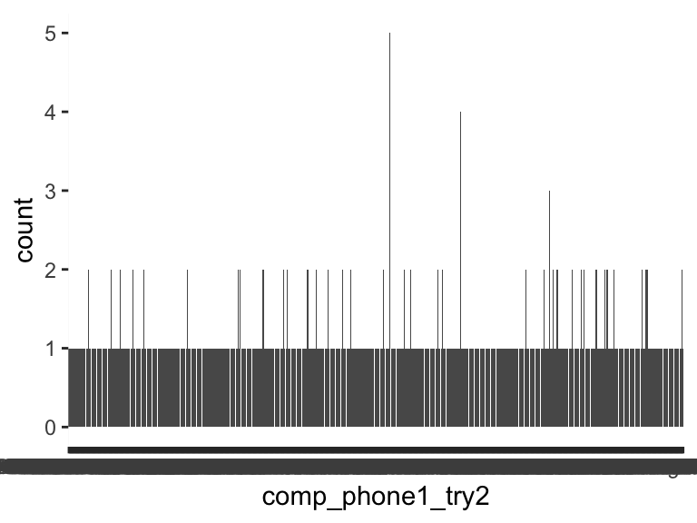

- Note that the following levels have at most five observations: "‘+৮৮০১৬০৫২২৮৩২২", "’+৮৮০১৭১২৫৫৮৮১১", "+88 01518758925", "+880 1973-909965", "+8801317018508", …, "Banglalink", "No", "অপ্রযোজ্য", "না", "লাগবে না" (557 values omitted).

## comp_phone2_try1

| Feature | Result |
| --- | --- |
| Variable type | character |
| Number of missing obs. | 576 (94.12 %) |
| Number of unique values | 35 |
| Mode | “01778346805” |

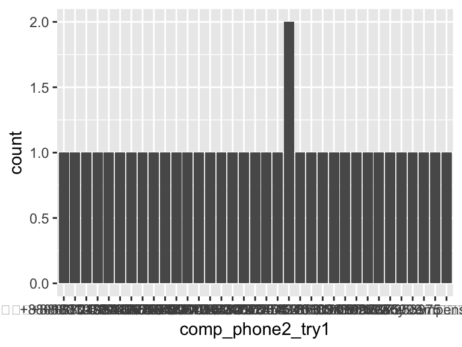

- Note that the following levels have at most five observations: "’+৮৮০১৯৩৩৮৪৩৪৬৪", "+8801683278262", "+8801724994179", "+8801952940355", "+8801981406769", …, "I don’t want any compensation", "চাই না", "বাংলাদেশ গ্রামীণফোন", "বুঝতে পারিনি", "হে" (25 values omitted).

## comp_phone2_try2

| Feature | Result |
| --- | --- |
| Variable type | character |
| Number of missing obs. | 576 (94.12 %) |
| Number of unique values | 36 |
| Mode | “+8801683278262” |

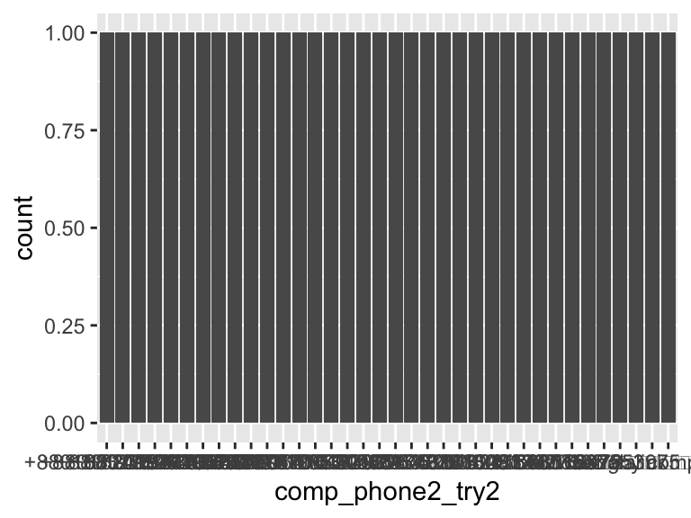

- Note that the following levels have at most five observations: "+8801683278262", "+8801724994179", "+8801933843464", "+8801952940355", "+8801981406769", …, "8801897953975", "banglalink", "I don’t want any compensation", "চাইনা", "বাড়িতে পেতে চায়" (26 values omitted).

## comp_phone3_try1

| Feature | Result |
| --- | --- |
| Variable type | character |
| Number of missing obs. | 606 (99.02 %) |
| Number of unique values | 5 |
| Mode | “গ্রামীনে” |

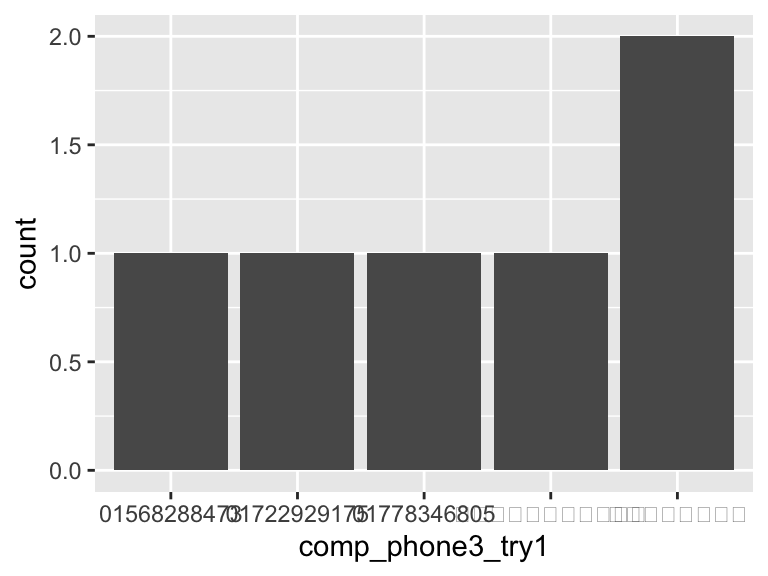

- Note that the following levels have at most five observations: "01568288473", "01722929175", "01778346805", "০১৯৩৩৮৪৩৪৬৪", "গ্রামীনে".

## comp_phone3_try2

| Feature | Result |
| --- | --- |
| Variable type | character |
| Number of missing obs. | 606 (99.02 %) |
| Number of unique values | 5 |
| Mode | “01763705040” |

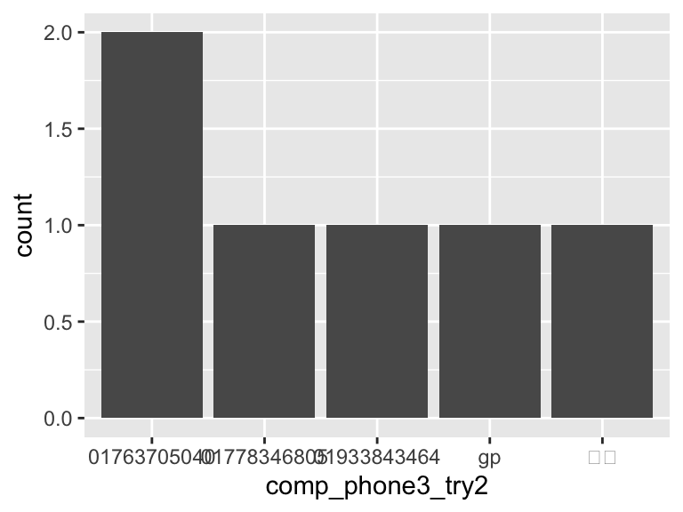

- Note that the following levels have at most five observations: "01763705040", "01778346805", "01933843464", "gp", "হে".

## geo_lat

| Feature | Result |
| --- | --- |
| Variable type | character |
| Number of missing obs. | 383 (62.58 %) |
| Number of unique values | 213 |
| Mode | “23.4416779” |

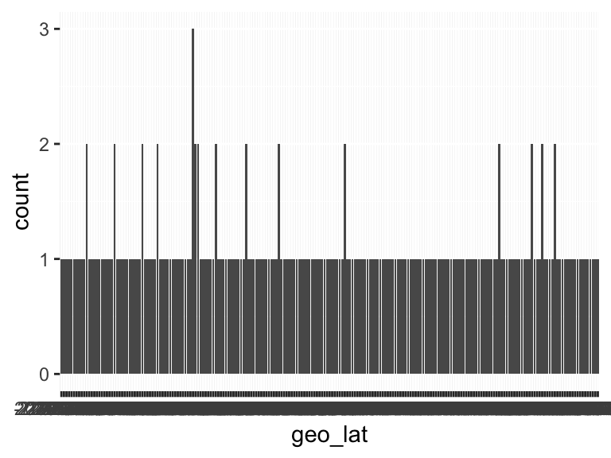

- Note that the following levels have at most five observations: "-7.8351606", "20.9700061", "21.4391383", "22.0161685", "22.178838", …, "25.8094545", "25.809745", "26.0292396", "26.3292006", "26.3367685" (203 values omitted).
- Note: The variable consists exclusively of numbers and takes a lot of different values. Is it perhaps a misclassified numeric variable?

## geo_lng

| Feature | Result |
| --- | --- |
| Variable type | character |
| Number of missing obs. | 383 (62.58 %) |
| Number of unique values | 213 |
| Mode | “89.5080243” |

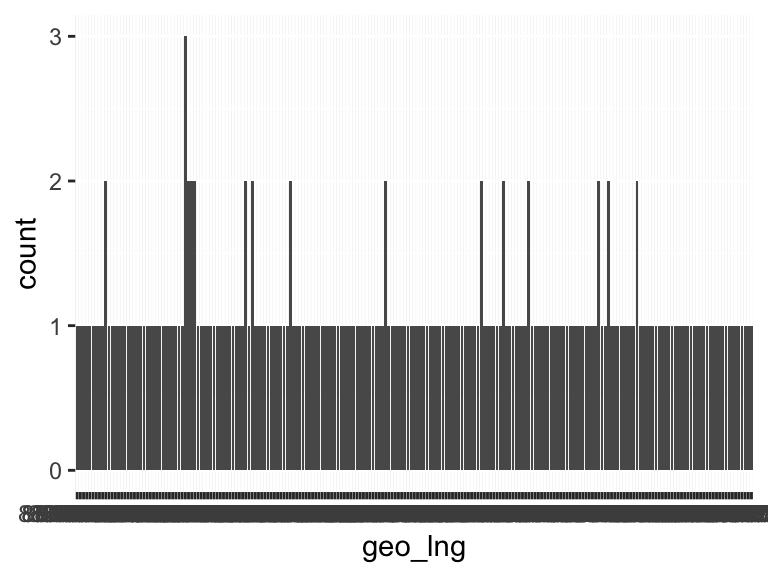

- Note that the following levels have at most five observations: "112.3778317", "88.269253", "88.2717377", "88.4688345", "88.548561", …, "92.0098669", "92.0103325", "92.1028962", "92.2481167", "92.3696622" (203 values omitted).
- Note: The variable consists exclusively of numbers and takes a lot of different values. Is it perhaps a misclassified numeric variable?

## q_url

| Feature | Result |
| --- | --- |
| Variable type | character |
| Number of missing obs. | 0 (0 %) |
| Number of unique values | 514 |
| Mode | “https://ucsb.co1.qualtrics.com/jfe/form/SV_1N3JWXFRMjZdDls?Q_Language=BN®ion=Dhaka+%28first+half%29&gender=Male&age=18&fbclid=IwAR1SbBIa5z1Eqbv6L305z3PLNdTHfCHmLuS3eCK2BreN30Q1pc10pmwgPN8_aem_AX_qu9U… |

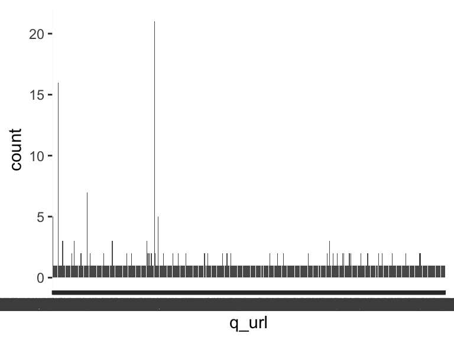

- Note that the following levels have at most five observations: "https://ucsb.co1.qualtrics.com/jfe/form/SV_1N3JWXFRMjZdDls\“, "https://ucsb.co1.qualtrics.com/jfe/form/SV_1N3JWXFRMjZdDls?fbclid=IwAR0__8S2iaKxXCvV6q03JWLMVdHZZFLPeURKHbogwzVSyDrSRPhw5HZmS9Y\”, "https://ucsb.co1.qualtrics.com/jfe/form/SV_1N3JWXFRMjZdDls?fbclid=IwAR03_k8p7Q7Hfxg5_v6M6mayYdp-6tqR_iFVe4RDOpAbG3ybcldY3Ll-Rdc\“, "https://ucsb.co1.qualtrics.com/jfe/form/SV_1N3JWXFRMjZdDls?fbclid=IwAR0eRIOcVjaRl_oxY0DKDMijVr_OVzw2CeQCtMF0hOaen-STXVM3MeM6pfo\”, "https://ucsb.co1.qualtrics.com/jfe/form/SV_1N3JWXFRMjZdDls?fbclid=IwAR0fBTsp9KOL3V0kUPcI5sTL6ErQaSNvGxmGnRqMrmqJvyRJOlEdenGKRWQ\“, …, "https://ucsb.co1.qualtrics.com/jfe/form/SV_1N3JWXFRMjZdDls?Q_Language=BN®ion=Sylhet&gender=Male&age=50&fbclid=IwAR2JybEkbpSndSThcBzm1fQmo5ontZxtGsHC8hsjR7Z3hdjBYAPHeUDh0Yc_aem_AW4zsWPBwW3SzbYWZt4dNJy7pE3nbge3NNX7ATuk5tluZGT5GGadVHRK-JmUuiefgjQY-vorjqihxfop03w1ubGi\”, "https://ucsb.co1.qualtrics.com/jfe/form/SV_1N3JWXFRMjZdDls?Q_Language=BN®ion=Sylhet&gender=Male&age=50&fbclid=IwAR2OLhWOeWzVoNarBwaXI4fwR7Ba0ca81dHTkDsyfzNMqmB4DzVzWUd-SYA_aem_AWoDUavWLxtBZtStwIsrnpMaqn89dFsgENDcq0l8OINfmUoHv29Jkgce9wYXLaaxs43uk04Lw1h95yq43SqSxaGw\“, "https://ucsb.co1.qualtrics.com/jfe/form/SV_1N3JWXFRMjZdDls?Q_Language=BN®ion=Sylhet&gender=Male&age=50&fbclid=IwAR2RpfLFNWs0YAnBXfhqXxllBrUagKEI2e2rlyxba_wNPOV3rpoyvvr0hWw_aem_AS8hbWhhb3AqHYyly6vQPEfoSR7Bl0aKs9jk9BictlkLE9c923eXKDvcsUNrjNTBkcC3fWfsxbdloUOntXb5vq_u\”, "https://ucsb.co1.qualtrics.com/jfe/form/SV_1N3JWXFRMjZdDls?Q_Language=BN®ion=Sylhet&gender=Male&age=50&fbclid=IwAR3rLoGBpoe_xxPyKzoRdAU4EvCbn-UrX6Cd49aISE6e-lGJKy2vXPecpno_aem_AQL-clGp2aAYz8AEFXsed-Z1pyxY27k7Tc_I8pceCoXQCEPU5PfvKZ2-gMY47iAcm0jZGIwwvozDWLHziqGl3Zpc\“, "https://ucsb.co1.qualtrics.com/jfe/form/SV_1N3JWXFRMjZdDls?Q_Language=BN®ion=Sylhet&gender=Male&age=50&fbclid=IwAR3XZZEzcl0y8dEHpFIDJchu2s5yvOY3-2DdVEQ9OHE0jv7mG8AtdLm-edA_aem_AQLq9-A1QmCEYimyQSZZ03O_XoFgoNdtSzGfIdn2j-A3W5l1fZ4JMOnMcRciapDOytY6O3oKk-3_8YoHZhPGTNxM\” (501 values omitted).

## q_language

| Feature | Result |
| --- | --- |
| Variable type | character |
| Number of missing obs. | 0 (0 %) |
| Number of unique values | 2 |
| Mode | “BN” |

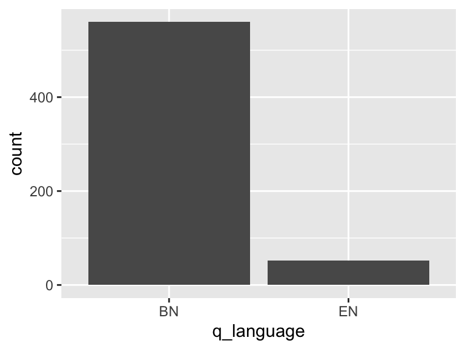

## gender

| Feature | Result |
| --- | --- |
| Variable type | character |
| Number of missing obs. | 53 (8.66 %) |
| Number of unique values | 2 |
| Mode | “Male” |

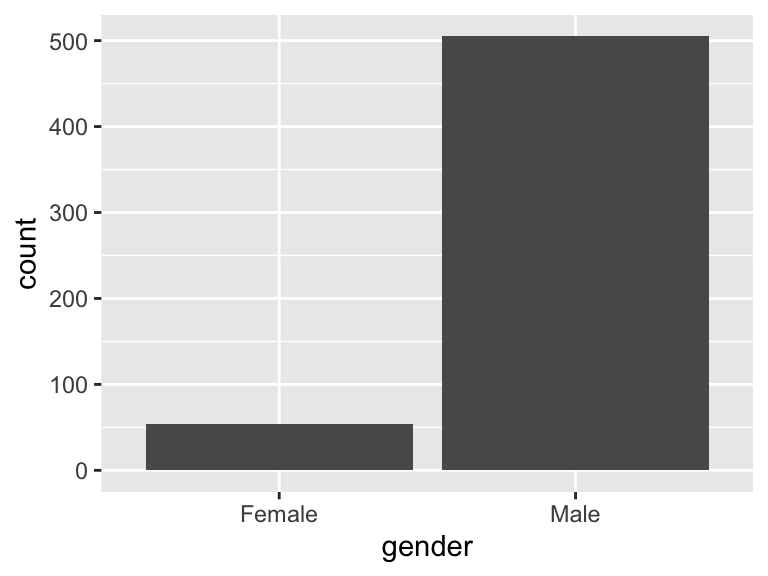

## region

| Feature | Result |
| --- | --- |
| Variable type | character |
| Number of missing obs. | 53 (8.66 %) |
| Number of unique values | 10 |
| Mode | “Sylhet” |

[figure not shown]

## age

| Feature | Result |
| --- | --- |
| Variable type | character |
| Number of missing obs. | 53 (8.66 %) |
| Number of unique values | 3 |
| Mode | “30” |

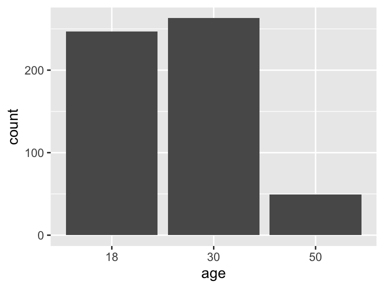

## geo_capability

- The variable only takes one value: "NA".

## geo_status

| Feature | Result |
| --- | --- |
| Variable type | character |
| Number of missing obs. | 0 (0 %) |
| Number of unique values | 3 |
| Mode | “-1” |

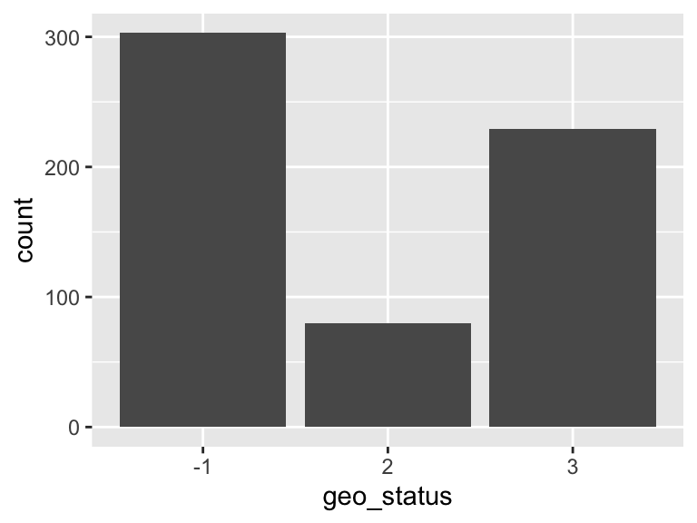

## geo_error

- The variable only takes one (non-missing) value: "error". The variable contains 50.33 % missing observations.

## country

- The variable only takes one value: "NA".

## no_surverys_submitted

| Feature | Result |
| --- | --- |
| Variable type | integer |
| Number of missing obs. | 0 (0 %) |
| Number of unique values | 8 |
| Median | 2 |
| 1st and 3rd quartiles | 2; 4 |
| Min. and max. | 2; 16 |

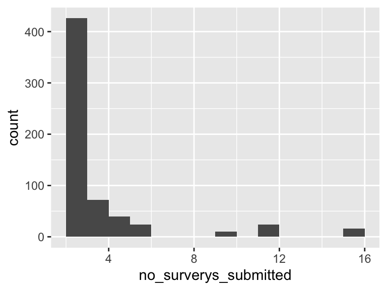

## income_brackets

| Feature | Result |
| --- | --- |
| Variable type | character |
| Number of missing obs. | 6 (0.98 %) |
| Number of unique values | 4 |
| Mode | “0% Tax Rate (Up to BDT 300,000)” |

[figure not shown]

Report generation information:

- Created by: Sofia Ingersoll (username: `sofiaingersoll`).
- Report creation time: Sun Apr 21 2024 23:35:58
- Report was run from directory: `/Users/sofiaingersoll/2035/Adaptation_Observatory/response_analysis/dataMaid`
- dataMaid v1.4.1 [Pkg: 2021-10-08 from CRAN (R 4.3.0)]
- R version 4.3.2 (2023-10-31).
- Platform: aarch64-apple-darwin20 (64-bit)(America/Los_Angeles).
- Function call: `makeDataReport(data = dup_ip_bgd, output = "html", replace = TRUE, reportTitle = "Bangladesh Adaptation Observation Duplicate IP Address Survey Responses, Retrieval Date 15 April 2024.")`